# Risk Factor Analysis

## Outcome Variable

**Outcome Variable:** ever_stunted

## Predictor Variables

**Intervention Variable:** tr.x

**Adjustment Set:**

unadjusted

## Stratifying Variables

The analysis was stratified on these variable(s):

- hdlvry
- agecat
- studyid
- country

## Data Summary

| hdlvry | agecat | studyid | country | tr.x | ever_stunted | n_cell | n |
| --- | --- | --- | --- | --- | --- | --- | --- |
| 1 | 0-6 months | ki1000125-AgaKhanUniv | PAKISTAN | Control | 0 | 69 | 192 |
| 1 | 0-6 months | ki1000125-AgaKhanUniv | PAKISTAN | Control | 1 | 28 | 192 |
| 1 | 0-6 months | ki1000125-AgaKhanUniv | PAKISTAN | Other | 0 | 77 | 192 |
| 1 | 0-6 months | ki1000125-AgaKhanUniv | PAKISTAN | Other | 1 | 18 | 192 |
| 0 | 0-6 months | ki1000125-AgaKhanUniv | PAKISTAN | Control | 0 | 29 | 97 |
| 0 | 0-6 months | ki1000125-AgaKhanUniv | PAKISTAN | Control | 1 | 12 | 97 |
| 0 | 0-6 months | ki1000125-AgaKhanUniv | PAKISTAN | Other | 0 | 38 | 97 |
| 0 | 0-6 months | ki1000125-AgaKhanUniv | PAKISTAN | Other | 1 | 18 | 97 |
| 0 | 0-6 months | ki1000304-ZnMort | INDIA | Other | 0 | 26 | 78 |
| 0 | 0-6 months | ki1000304-ZnMort | INDIA | Other | 1 | 13 | 78 |
| 0 | 0-6 months | ki1000304-ZnMort | INDIA | Zinc | 0 | 22 | 78 |
| 0 | 0-6 months | ki1000304-ZnMort | INDIA | Zinc | 1 | 17 | 78 |
| 1 | 0-6 months | ki1000304-ZnMort | INDIA | Other | 0 | 28 | 103 |
| 1 | 0-6 months | ki1000304-ZnMort | INDIA | Other | 1 | 22 | 103 |
| 1 | 0-6 months | ki1000304-ZnMort | INDIA | Zinc | 0 | 33 | 103 |
| 1 | 0-6 months | ki1000304-ZnMort | INDIA | Zinc | 1 | 20 | 103 |
| 1 | 0-6 months | ki1000304b-SAS-CompFeed | INDIA | Control | 0 | 185 | 564 |
| 1 | 0-6 months | ki1000304b-SAS-CompFeed | INDIA | Control | 1 | 72 | 564 |
| 1 | 0-6 months | ki1000304b-SAS-CompFeed | INDIA | Other | 0 | 213 | 564 |
| 1 | 0-6 months | ki1000304b-SAS-CompFeed | INDIA | Other | 1 | 94 | 564 |
| 0 | 0-6 months | ki1000304b-SAS-CompFeed | INDIA | Control | 0 | 48 | 85 |
| 0 | 0-6 months | ki1000304b-SAS-CompFeed | INDIA | Control | 1 | 19 | 85 |
| 0 | 0-6 months | ki1000304b-SAS-CompFeed | INDIA | Other | 0 | 13 | 85 |
| 0 | 0-6 months | ki1000304b-SAS-CompFeed | INDIA | Other | 1 | 5 | 85 |
| 1 | 0-6 months | ki1000304b-SAS-FoodSuppl | INDIA | Control | 0 | 45 | 335 |
| 1 | 0-6 months | ki1000304b-SAS-FoodSuppl | INDIA | Control | 1 | 35 | 335 |
| 1 | 0-6 months | ki1000304b-SAS-FoodSuppl | INDIA | Other | 0 | 154 | 335 |
| 1 | 0-6 months | ki1000304b-SAS-FoodSuppl | INDIA | Other | 1 | 101 | 335 |
| 0 | 0-6 months | ki1000304b-SAS-FoodSuppl | INDIA | Control | 0 | 18 | 81 |
| 0 | 0-6 months | ki1000304b-SAS-FoodSuppl | INDIA | Control | 1 | 7 | 81 |

[output cut: 226 more lines]

The following strata were considered:

- hdlvry: 0, agecat: 0-24 months, studyid: ki1000125-AgaKhanUniv, country: PAKISTAN
- hdlvry: 0, agecat: 0-24 months, studyid: ki1000304-ZnMort, country: INDIA
- hdlvry: 0, agecat: 0-24 months, studyid: ki1000304b-SAS-CompFeed, country: INDIA
- hdlvry: 0, agecat: 0-24 months, studyid: ki1000304b-SAS-FoodSuppl, country: INDIA
- hdlvry: 0, agecat: 0-24 months, studyid: ki1017093b-PROVIDE, country: BANGLADESH
- hdlvry: 0, agecat: 0-24 months, studyid: ki1066203-TanzaniaChild2, country: TANZANIA, UNITED REPUBLIC OF
- hdlvry: 0, agecat: 0-24 months, studyid: ki1148112-iLiNS-DYAD-M, country: MALAWI
- hdlvry: 0, agecat: 0-24 months, studyid: kiGH5241-JiVitA-3, country: BANGLADESH
- hdlvry: 0, agecat: 0-24 months, studyid: kiGH5241-JiVitA-4, country: BANGLADESH
- hdlvry: 0, agecat: 0-6 months, studyid: ki1000125-AgaKhanUniv, country: PAKISTAN
- hdlvry: 0, agecat: 0-6 months, studyid: ki1000304-ZnMort, country: INDIA
- hdlvry: 0, agecat: 0-6 months, studyid: ki1000304b-SAS-CompFeed, country: INDIA
- hdlvry: 0, agecat: 0-6 months, studyid: ki1000304b-SAS-FoodSuppl, country: INDIA
- hdlvry: 0, agecat: 0-6 months, studyid: ki1017093b-PROVIDE, country: BANGLADESH
- hdlvry: 0, agecat: 0-6 months, studyid: ki1066203-TanzaniaChild2, country: TANZANIA, UNITED REPUBLIC OF
- hdlvry: 0, agecat: 0-6 months, studyid: ki1148112-iLiNS-DYAD-M, country: MALAWI
- hdlvry: 0, agecat: 0-6 months, studyid: kiGH5241-JiVitA-3, country: BANGLADESH
- hdlvry: 0, agecat: 0-6 months, studyid: kiGH5241-JiVitA-4, country: BANGLADESH
- hdlvry: 0, agecat: 6-24 months, studyid: ki1000125-AgaKhanUniv, country: PAKISTAN
- hdlvry: 0, agecat: 6-24 months, studyid: ki1000304-ZnMort, country: INDIA
- hdlvry: 0, agecat: 6-24 months, studyid: ki1000304b-SAS-CompFeed, country: INDIA
- hdlvry: 0, agecat: 6-24 months, studyid: ki1000304b-SAS-FoodSuppl, country: INDIA
- hdlvry: 0, agecat: 6-24 months, studyid: ki1017093b-PROVIDE, country: BANGLADESH
- hdlvry: 0, agecat: 6-24 months, studyid: ki1066203-TanzaniaChild2, country: TANZANIA, UNITED REPUBLIC OF
- hdlvry: 0, agecat: 6-24 months, studyid: ki1148112-iLiNS-DYAD-M, country: MALAWI
- hdlvry: 0, agecat: 6-24 months, studyid: kiGH5241-JiVitA-3, country: BANGLADESH
- hdlvry: 0, agecat: 6-24 months, studyid: kiGH5241-JiVitA-4, country: BANGLADESH
- hdlvry: 1, agecat: 0-24 months, studyid: ki1000125-AgaKhanUniv, country: PAKISTAN
- hdlvry: 1, agecat: 0-24 months, studyid: ki1000304-ZnMort, country: INDIA
- hdlvry: 1, agecat: 0-24 months, studyid: ki1000304b-SAS-CompFeed, country: INDIA
- hdlvry: 1, agecat: 0-24 months, studyid: ki1000304b-SAS-FoodSuppl, country: INDIA
- hdlvry: 1, agecat: 0-24 months, studyid: ki1017093b-PROVIDE, country: BANGLADESH
- hdlvry: 1, agecat: 0-24 months, studyid: ki1066203-TanzaniaChild2, country: TANZANIA, UNITED REPUBLIC OF
- hdlvry: 1, agecat: 0-24 months, studyid: ki1148112-iLiNS-DYAD-M, country: MALAWI
- hdlvry: 1, agecat: 0-24 months, studyid: kiGH5241-JiVitA-3, country: BANGLADESH
- hdlvry: 1, agecat: 0-24 months, studyid: kiGH5241-JiVitA-4, country: BANGLADESH
- hdlvry: 1, agecat: 0-6 months, studyid: ki1000125-AgaKhanUniv, country: PAKISTAN
- hdlvry: 1, agecat: 0-6 months, studyid: ki1000304-ZnMort, country: INDIA
- hdlvry: 1, agecat: 0-6 months, studyid: ki1000304b-SAS-CompFeed, country: INDIA
- hdlvry: 1, agecat: 0-6 months, studyid: ki1000304b-SAS-FoodSuppl, country: INDIA
- hdlvry: 1, agecat: 0-6 months, studyid: ki1017093b-PROVIDE, country: BANGLADESH
- hdlvry: 1, agecat: 0-6 months, studyid: ki1066203-TanzaniaChild2, country: TANZANIA, UNITED REPUBLIC OF
- hdlvry: 1, agecat: 0-6 months, studyid: ki1148112-iLiNS-DYAD-M, country: MALAWI
- hdlvry: 1, agecat: 0-6 months, studyid: kiGH5241-JiVitA-3, country: BANGLADESH
- hdlvry: 1, agecat: 0-6 months, studyid: kiGH5241-JiVitA-4, country: BANGLADESH
- hdlvry: 1, agecat: 6-24 months, studyid: ki1000125-AgaKhanUniv, country: PAKISTAN
- hdlvry: 1, agecat: 6-24 months, studyid: ki1000304-ZnMort, country: INDIA
- hdlvry: 1, agecat: 6-24 months, studyid: ki1000304b-SAS-CompFeed, country: INDIA
- hdlvry: 1, agecat: 6-24 months, studyid: ki1000304b-SAS-FoodSuppl, country: INDIA
- hdlvry: 1, agecat: 6-24 months, studyid: ki1017093b-PROVIDE, country: BANGLADESH
- hdlvry: 1, agecat: 6-24 months, studyid: ki1066203-TanzaniaChild2, country: TANZANIA, UNITED REPUBLIC OF
- hdlvry: 1, agecat: 6-24 months, studyid: ki1148112-iLiNS-DYAD-M, country: MALAWI
- hdlvry: 1, agecat: 6-24 months, studyid: kiGH5241-JiVitA-3, country: BANGLADESH
- hdlvry: 1, agecat: 6-24 months, studyid: kiGH5241-JiVitA-4, country: BANGLADESH

### Dropped Strata

Some strata were dropped due to rare outcomes:

- hdlvry: 1, agecat: 0-6 months, studyid: ki1066203-TanzaniaChild2, country: TANZANIA, UNITED REPUBLIC OF
- hdlvry: 1, agecat: 0-6 months, studyid: ki1148112-iLiNS-DYAD-M, country: MALAWI
- hdlvry: 0, agecat: 0-6 months, studyid: ki1148112-iLiNS-DYAD-M, country: MALAWI
- hdlvry: 0, agecat: 0-6 months, studyid: kiGH5241-JiVitA-3, country: BANGLADESH
- hdlvry: 0, agecat: 6-24 months, studyid: ki1000304b-SAS-CompFeed, country: INDIA
- hdlvry: 1, agecat: 6-24 months, studyid: ki1066203-TanzaniaChild2, country: TANZANIA, UNITED REPUBLIC OF
- hdlvry: 0, agecat: 6-24 months, studyid: kiGH5241-JiVitA-3, country: BANGLADESH
- hdlvry: 1, agecat: 0-24 months, studyid: ki1066203-TanzaniaChild2, country: TANZANIA, UNITED REPUBLIC OF

## Methods Detail

We’re interested in the causal parameters $E[Y_a]$ for all values of $a \in \mathcal{A}$. These parameters represent the mean outcome if, possibly contrary to fact, we intervened to set all units to have $A=a$. Under the randomization and positivity assumptions, these are identified by the statistical parameters $\psi_a=E_W[E_{Y|A,W}(Y|A=a,W)]$. In addition, we’re interested in the mean of $Y$, $E[Y]$ under no intervention (the observed mean). We will estimate these parameters by using SuperLearner to fit the relevant likelihood factors – $E_{Y|A,W}(Y|A=a,W)$ and $p(A=a|W)$, and then updating our likelihood fit using a joint TMLE.

For unadjusted analyses ($W=\{\}$), initial likelihoods were estimated using Lrnr_glm to estimate the simple $E(Y|A)$ and Lrnr_mean to estimate $p(A)$. For adjusted analyses, a small library containing Lrnr_glmnet, Lrnr_xgboost, and Lrnr_mean was used.

Having estimated these parameters, we will then use the delta method to estimate relative risks and attributable risks relative to a prespecified baseline level of $A$.

[output not shown]

# Results Detail

## Results Plots

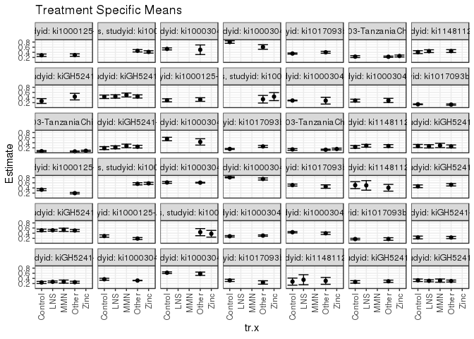

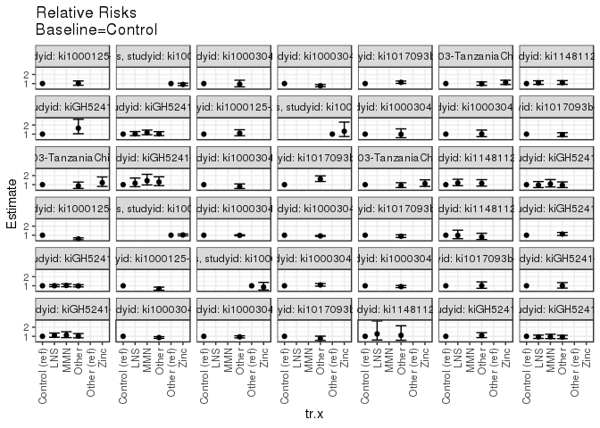

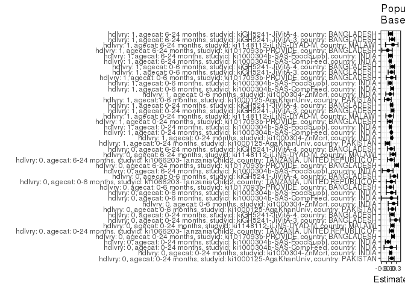

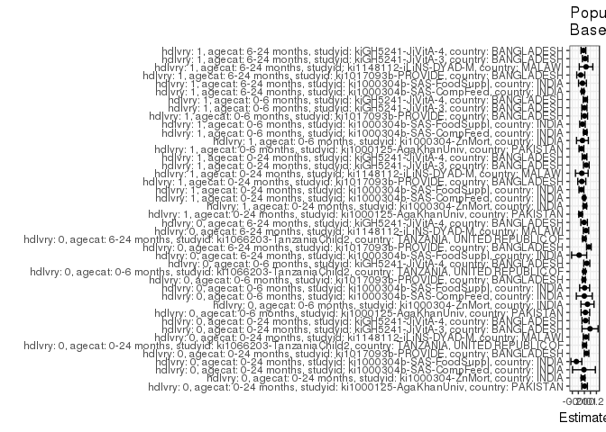

## Results Table

### Parameter: TSM

| hdlvry | agecat | studyid | country | intervention_level | baseline_level | estimate | ci_lower | ci_upper |
| --- | --- | --- | --- | --- | --- | --- | --- | --- |
| 0 | 0-24 months | ki1000125-AgaKhanUniv | PAKISTAN | Control | NA | 0.2857143 | 0.2386590 | 0.3327695 |
| 0 | 0-24 months | ki1000125-AgaKhanUniv | PAKISTAN | Other | NA | 0.2921348 | 0.2452916 | 0.3389781 |
| 0 | 0-24 months | ki1000304-ZnMort | INDIA | Other | NA | 0.4593407 | 0.4135253 | 0.5051561 |
| 0 | 0-24 months | ki1000304-ZnMort | INDIA | Zinc | NA | 0.4146341 | 0.3691410 | 0.4601273 |
| 0 | 0-24 months | ki1000304b-SAS-CompFeed | INDIA | Control | NA | 0.5324675 | 0.4932721 | 0.5716630 |
| 0 | 0-24 months | ki1000304b-SAS-CompFeed | INDIA | Other | NA | 0.5000000 | 0.3125448 | 0.6874552 |
| 0 | 0-24 months | ki1000304b-SAS-FoodSuppl | INDIA | Control | NA | 0.8000000 | 0.7513043 | 0.8486957 |
| 0 | 0-24 months | ki1000304b-SAS-FoodSuppl | INDIA | Other | NA | 0.6071429 | 0.5181577 | 0.6961280 |
| 0 | 0-24 months | ki1017093b-PROVIDE | BANGLADESH | Control | NA | 0.3520000 | 0.3301284 | 0.3738716 |
| 0 | 0-24 months | ki1017093b-PROVIDE | BANGLADESH | Other | NA | 0.4011299 | 0.3633573 | 0.4389025 |
| 0 | 0-24 months | ki1066203-TanzaniaChild2 | TANZANIA, UNITED REPUBLIC OF | Control | NA | 0.2319392 | 0.1958611 | 0.2680172 |
| 0 | 0-24 months | ki1066203-TanzaniaChild2 | TANZANIA, UNITED REPUBLIC OF | Other | NA | 0.2270115 | 0.2015952 | 0.2524277 |
| 0 | 0-24 months | ki1066203-TanzaniaChild2 | TANZANIA, UNITED REPUBLIC OF | Zinc | NA | 0.2560748 | 0.2190815 | 0.2930680 |
| 0 | 0-24 months | ki1148112-iLiNS-DYAD-M | MALAWI | Control | NA | 0.4072848 | 0.3517823 | 0.4627873 |
| 0 | 0-24 months | ki1148112-iLiNS-DYAD-M | MALAWI | LNS | NA | 0.4437690 | 0.3900628 | 0.4974752 |
| 0 | 0-24 months | ki1148112-iLiNS-DYAD-M | MALAWI | Other | NA | 0.4477124 | 0.3919084 | 0.5035164 |
| 0 | 0-24 months | kiGH5241-JiVitA-3 | BANGLADESH | Control | NA | 0.2631579 | 0.1694087 | 0.3569071 |
| 0 | 0-24 months | kiGH5241-JiVitA-3 | BANGLADESH | Other | NA | 0.4347826 | 0.3067971 | 0.5627681 |
| 0 | 0-24 months | kiGH5241-JiVitA-4 | BANGLADESH | Control | NA | 0.4290541 | 0.3616819 | 0.4964262 |
| 0 | 0-24 months | kiGH5241-JiVitA-4 | BANGLADESH | LNS | NA | 0.4415205 | 0.3749824 | 0.5080586 |
| 0 | 0-24 months | kiGH5241-JiVitA-4 | BANGLADESH | MMN | NA | 0.4974874 | 0.4213450 | 0.5736299 |
| 0 | 0-24 months | kiGH5241-JiVitA-4 | BANGLADESH | Other | NA | 0.4414414 | 0.3794000 | 0.5034829 |
| 0 | 0-6 months | ki1000125-AgaKhanUniv | PAKISTAN | Control | NA | 0.2926829 | 0.2335098 | 0.3518560 |
| 0 | 0-6 months | ki1000125-AgaKhanUniv | PAKISTAN | Other | NA | 0.3214286 | 0.2504445 | 0.3924126 |
| 0 | 0-6 months | ki1000304-ZnMort | INDIA | Other | NA | 0.3333333 | 0.1844276 | 0.4822391 |
| 0 | 0-6 months | ki1000304-ZnMort | INDIA | Zinc | NA | 0.4358974 | 0.2792624 | 0.5925325 |
| 0 | 0-6 months | ki1000304b-SAS-CompFeed | INDIA | Control | NA | 0.2835821 | 0.2692116 | 0.2979526 |
| 0 | 0-6 months | ki1000304b-SAS-CompFeed | INDIA | Other | NA | 0.2777778 | 0.1454939 | 0.4100616 |
| 0 | 0-6 months | ki1000304b-SAS-FoodSuppl | INDIA | Control | NA | 0.2800000 | 0.2253392 | 0.3346608 |
| 0 | 0-6 months | ki1000304b-SAS-FoodSuppl | INDIA | Other | NA | 0.2857143 | 0.2034035 | 0.3680250 |

[output cut: 73 more lines]

### Parameter: E(Y)

| hdlvry | agecat | studyid | country | intervention_level | baseline_level | estimate | ci_lower | ci_upper |
| --- | --- | --- | --- | --- | --- | --- | --- | --- |
| 0 | 0-24 months | ki1000125-AgaKhanUniv | PAKISTAN | NA | NA | 0.2888889 | 0.2224908 | 0.3552870 |
| 0 | 0-24 months | ki1000304-ZnMort | INDIA | NA | NA | 0.4370861 | 0.4047693 | 0.4694029 |
| 0 | 0-24 months | ki1000304b-SAS-CompFeed | INDIA | NA | NA | 0.5252525 | 0.3271740 | 0.7233310 |
| 0 | 0-24 months | ki1000304b-SAS-FoodSuppl | INDIA | NA | NA | 0.6666667 | 0.5633675 | 0.7699658 |
| 0 | 0-24 months | ki1017093b-PROVIDE | BANGLADESH | NA | NA | 0.3883090 | 0.3446183 | 0.4319997 |
| 0 | 0-24 months | ki1066203-TanzaniaChild2 | TANZANIA, UNITED REPUBLIC OF | NA | NA | 0.2356295 | 0.2174955 | 0.2537634 |
| 0 | 0-24 months | ki1148112-iLiNS-DYAD-M | MALAWI | NA | NA | 0.4332978 | 0.4015314 | 0.4650641 |
| 0 | 0-24 months | kiGH5241-JiVitA-3 | BANGLADESH | NA | NA | 0.3571429 | 0.1950951 | 0.5191906 |
| 0 | 0-24 months | kiGH5241-JiVitA-4 | BANGLADESH | NA | NA | 0.4478632 | 0.4139564 | 0.4817701 |
| 0 | 0-6 months | ki1000125-AgaKhanUniv | PAKISTAN | NA | NA | 0.3092784 | 0.2168216 | 0.4017351 |
| 0 | 0-6 months | ki1000304-ZnMort | INDIA | NA | NA | 0.3846154 | 0.2759505 | 0.4932803 |
| 0 | 0-6 months | ki1000304b-SAS-CompFeed | INDIA | NA | NA | 0.2823529 | 0.1482885 | 0.4164173 |
| 0 | 0-6 months | ki1000304b-SAS-FoodSuppl | INDIA | NA | NA | 0.2839506 | 0.1851417 | 0.3827595 |
| 0 | 0-6 months | ki1017093b-PROVIDE | BANGLADESH | NA | NA | 0.1276151 | 0.0976722 | 0.1575580 |
| 0 | 0-6 months | ki1066203-TanzaniaChild2 | TANZANIA, UNITED REPUBLIC OF | NA | NA | 0.0705036 | 0.0595128 | 0.0814944 |
| 0 | 0-6 months | kiGH5241-JiVitA-4 | BANGLADESH | NA | NA | 0.2306940 | 0.2011200 | 0.2602681 |
| 0 | 6-24 months | ki1000304b-SAS-FoodSuppl | INDIA | NA | NA | 0.4583333 | 0.3158855 | 0.6007812 |
| 0 | 6-24 months | ki1017093b-PROVIDE | BANGLADESH | NA | NA | 0.2321900 | 0.1896252 | 0.2747548 |
| 0 | 6-24 months | ki1066203-TanzaniaChild2 | TANZANIA, UNITED REPUBLIC OF | NA | NA | 0.1381312 | 0.1218345 | 0.1544278 |
| 0 | 6-24 months | ki1148112-iLiNS-DYAD-M | MALAWI | NA | NA | 0.2644737 | 0.2330623 | 0.2958851 |
| 0 | 6-24 months | kiGH5241-JiVitA-4 | BANGLADESH | NA | NA | 0.2674180 | 0.2346912 | 0.3001449 |
| 1 | 0-24 months | ki1000125-AgaKhanUniv | PAKISTAN | NA | NA | 0.2701149 | 0.2233969 | 0.3168330 |
| 1 | 0-24 months | ki1000304-ZnMort | INDIA | NA | NA | 0.5707965 | 0.5419247 | 0.5996682 |
| 1 | 0-24 months | ki1000304b-SAS-CompFeed | INDIA | NA | NA | 0.6099398 | 0.5725014 | 0.6473781 |
| 1 | 0-24 months | ki1000304b-SAS-FoodSuppl | INDIA | NA | NA | 0.7655786 | 0.7202814 | 0.8108759 |
| 1 | 0-24 months | ki1017093b-PROVIDE | BANGLADESH | NA | NA | 0.4691358 | 0.3920497 | 0.5462219 |
| 1 | 0-24 months | ki1148112-iLiNS-DYAD-M | MALAWI | NA | NA | 0.4666667 | 0.3821975 | 0.5511359 |
| 1 | 0-24 months | kiGH5241-JiVitA-3 | BANGLADESH | NA | NA | 0.4967320 | 0.4258046 | 0.5676595 |
| 1 | 0-24 months | kiGH5241-JiVitA-4 | BANGLADESH | NA | NA | 0.5133674 | 0.4913579 | 0.5353769 |
| 1 | 0-6 months | ki1000125-AgaKhanUniv | PAKISTAN | NA | NA | 0.2395833 | 0.1790513 | 0.3001154 |
| 1 | 0-6 months | ki1000304-ZnMort | INDIA | NA | NA | 0.4077670 | 0.3123995 | 0.5031345 |
| 1 | 0-6 months | ki1000304b-SAS-CompFeed | INDIA | NA | NA | 0.2943262 | 0.2527095 | 0.3359430 |
| 1 | 0-6 months | ki1000304b-SAS-FoodSuppl | INDIA | NA | NA | 0.4059701 | 0.3533047 | 0.4586356 |
| 1 | 0-6 months | ki1017093b-PROVIDE | BANGLADESH | NA | NA | 0.1728395 | 0.1144343 | 0.2312447 |
| 1 | 0-6 months | kiGH5241-JiVitA-3 | BANGLADESH | NA | NA | 0.2320675 | 0.1628310 | 0.3013040 |
| 1 | 0-6 months | kiGH5241-JiVitA-4 | BANGLADESH | NA | NA | 0.2572999 | 0.2371382 | 0.2774616 |
| 1 | 6-24 months | ki1000304b-SAS-CompFeed | INDIA | NA | NA | 0.3394077 | 0.2992701 | 0.3795454 |
| 1 | 6-24 months | ki1000304b-SAS-FoodSuppl | INDIA | NA | NA | 0.5898876 | 0.5174278 | 0.6623475 |
| 1 | 6-24 months | ki1017093b-PROVIDE | BANGLADESH | NA | NA | 0.2627119 | 0.1829650 | 0.3424587 |
| 1 | 6-24 months | ki1148112-iLiNS-DYAD-M | MALAWI | NA | NA | 0.3027523 | 0.2161013 | 0.3894033 |
| 1 | 6-24 months | kiGH5241-JiVitA-3 | BANGLADESH | NA | NA | 0.2758621 | 0.2087515 | 0.3429726 |
| 1 | 6-24 months | kiGH5241-JiVitA-4 | BANGLADESH | NA | NA | 0.3102119 | 0.2874603 | 0.3329636 |

### Parameter: RR

| hdlvry | agecat | studyid | country | intervention_level | baseline_level | estimate | ci_lower | ci_upper |
| --- | --- | --- | --- | --- | --- | --- | --- | --- |
| 0 | 0-24 months | ki1000125-AgaKhanUniv | PAKISTAN | Control | Control | 1.0000000 | 1.0000000 | 1.0000000 |
| 0 | 0-24 months | ki1000125-AgaKhanUniv | PAKISTAN | Other | Control | 1.0224719 | 0.8125024 | 1.2867024 |
| 0 | 0-24 months | ki1000304-ZnMort | INDIA | Other | Other | 1.0000000 | 1.0000000 | 1.0000000 |
| 0 | 0-24 months | ki1000304-ZnMort | INDIA | Zinc | Other | 0.9026724 | 0.7782758 | 1.0469522 |
| 0 | 0-24 months | ki1000304b-SAS-CompFeed | INDIA | Control | Control | 1.0000000 | 1.0000000 | 1.0000000 |
| 0 | 0-24 months | ki1000304b-SAS-CompFeed | INDIA | Other | Control | 0.9390244 | 0.6445111 | 1.3681173 |
| 0 | 0-24 months | ki1000304b-SAS-FoodSuppl | INDIA | Control | Control | 1.0000000 | 1.0000000 | 1.0000000 |
| 0 | 0-24 months | ki1000304b-SAS-FoodSuppl | INDIA | Other | Control | 0.7589286 | 0.6475568 | 0.8894549 |
| 0 | 0-24 months | ki1017093b-PROVIDE | BANGLADESH | Control | Control | 1.0000000 | 1.0000000 | 1.0000000 |
| 0 | 0-24 months | ki1017093b-PROVIDE | BANGLADESH | Other | Control | 1.1395737 | 1.0179962 | 1.2756710 |
| 0 | 0-24 months | ki1066203-TanzaniaChild2 | TANZANIA, UNITED REPUBLIC OF | Control | Control | 1.0000000 | 1.0000000 | 1.0000000 |
| 0 | 0-24 months | ki1066203-TanzaniaChild2 | TANZANIA, UNITED REPUBLIC OF | Other | Control | 0.9787545 | 0.8080533 | 1.1855162 |
| 0 | 0-24 months | ki1066203-TanzaniaChild2 | TANZANIA, UNITED REPUBLIC OF | Zinc | Control | 1.1040601 | 0.8928906 | 1.3651713 |
| 0 | 0-24 months | ki1148112-iLiNS-DYAD-M | MALAWI | Control | Control | 1.0000000 | 1.0000000 | 1.0000000 |
| 0 | 0-24 months | ki1148112-iLiNS-DYAD-M | MALAWI | LNS | Control | 1.0895792 | 0.9080422 | 1.3074093 |
| 0 | 0-24 months | ki1148112-iLiNS-DYAD-M | MALAWI | Other | Control | 1.0992614 | 0.9138938 | 1.3222276 |
| 0 | 0-24 months | kiGH5241-JiVitA-3 | BANGLADESH | Control | Control | 1.0000000 | 1.0000000 | 1.0000000 |
| 0 | 0-24 months | kiGH5241-JiVitA-3 | BANGLADESH | Other | Control | 1.6521739 | 1.0408164 | 2.6226323 |
| 0 | 0-24 months | kiGH5241-JiVitA-4 | BANGLADESH | Control | Control | 1.0000000 | 1.0000000 | 1.0000000 |
| 0 | 0-24 months | kiGH5241-JiVitA-4 | BANGLADESH | LNS | Control | 1.0290556 | 0.8277744 | 1.2792801 |
| 0 | 0-24 months | kiGH5241-JiVitA-4 | BANGLADESH | MMN | Control | 1.1594983 | 0.9312024 | 1.4437637 |
| 0 | 0-24 months | kiGH5241-JiVitA-4 | BANGLADESH | Other | Control | 1.0288714 | 0.8333672 | 1.2702399 |
| 0 | 0-6 months | ki1000125-AgaKhanUniv | PAKISTAN | Control | Control | 1.0000000 | 1.0000000 | 1.0000000 |
| 0 | 0-6 months | ki1000125-AgaKhanUniv | PAKISTAN | Other | Control | 1.0982143 | 0.8140597 | 1.4815555 |
| 0 | 0-6 months | ki1000304-ZnMort | INDIA | Other | Other | 1.0000000 | 1.0000000 | 1.0000000 |
| 0 | 0-6 months | ki1000304-ZnMort | INDIA | Zinc | Other | 1.3076923 | 0.7370916 | 2.3200089 |
| 0 | 0-6 months | ki1000304b-SAS-CompFeed | INDIA | Control | Control | 1.0000000 | 1.0000000 | 1.0000000 |
| 0 | 0-6 months | ki1000304b-SAS-CompFeed | INDIA | Other | Control | 0.9795322 | 0.6081937 | 1.5775949 |
| 0 | 0-6 months | ki1000304b-SAS-FoodSuppl | INDIA | Control | Control | 1.0000000 | 1.0000000 | 1.0000000 |
| 0 | 0-6 months | ki1000304b-SAS-FoodSuppl | INDIA | Other | Control | 1.0204082 | 0.7205089 | 1.4451353 |

[output cut: 73 more lines]

### Parameter: PAR

| hdlvry | agecat | studyid | country | intervention_level | baseline_level | estimate | ci_lower | ci_upper |
| --- | --- | --- | --- | --- | --- | --- | --- | --- |
| 0 | 0-24 months | ki1000125-AgaKhanUniv | PAKISTAN | Control | NA | 0.0031746 | -0.0436710 | 0.0500202 |
| 0 | 0-24 months | ki1000304-ZnMort | INDIA | Other | NA | -0.0222546 | -0.0544277 | 0.0099185 |
| 0 | 0-24 months | ki1000304b-SAS-CompFeed | INDIA | Control | NA | -0.0072150 | -0.1968762 | 0.1824462 |
| 0 | 0-24 months | ki1000304b-SAS-FoodSuppl | INDIA | Control | NA | -0.1333333 | -0.2244346 | -0.0422320 |
| 0 | 0-24 months | ki1017093b-PROVIDE | BANGLADESH | Control | NA | 0.0363090 | -0.0015131 | 0.0741311 |
| 0 | 0-24 months | ki1066203-TanzaniaChild2 | TANZANIA, UNITED REPUBLIC OF | Control | NA | 0.0036903 | -0.0276141 | 0.0349946 |
| 0 | 0-24 months | ki1148112-iLiNS-DYAD-M | MALAWI | Control | NA | 0.0260130 | -0.0198552 | 0.0718812 |
| 0 | 0-24 months | kiGH5241-JiVitA-3 | BANGLADESH | Control | NA | 0.0939850 | -0.0388698 | 0.2268397 |
| 0 | 0-24 months | kiGH5241-JiVitA-4 | BANGLADESH | Control | NA | 0.0188092 | -0.0394481 | 0.0770665 |
| 0 | 0-6 months | ki1000125-AgaKhanUniv | PAKISTAN | Control | NA | 0.0165954 | -0.0544454 | 0.0876363 |
| 0 | 0-6 months | ki1000304-ZnMort | INDIA | Other | NA | 0.0512821 | -0.0573829 | 0.1599470 |
| 0 | 0-6 months | ki1000304b-SAS-CompFeed | INDIA | Control | NA | -0.0012291 | -0.1337239 | 0.1312656 |
| 0 | 0-6 months | ki1000304b-SAS-FoodSuppl | INDIA | Control | NA | 0.0039506 | -0.0783622 | 0.0862634 |
| 0 | 0-6 months | ki1017093b-PROVIDE | BANGLADESH | Control | NA | -0.0083849 | -0.0338626 | 0.0170928 |
| 0 | 0-6 months | ki1066203-TanzaniaChild2 | TANZANIA, UNITED REPUBLIC OF | Control | NA | -0.0005137 | -0.0195990 | 0.0185717 |
| 0 | 0-6 months | kiGH5241-JiVitA-4 | BANGLADESH | Control | NA | 0.0392878 | -0.0110461 | 0.0896217 |
| 0 | 6-24 months | ki1000304b-SAS-FoodSuppl | INDIA | Control | NA | -0.0871212 | -0.2122110 | 0.0379686 |
| 0 | 6-24 months | ki1017093b-PROVIDE | BANGLADESH | Control | NA | 0.0742952 | 0.0359148 | 0.1126757 |
| 0 | 6-24 months | ki1066203-TanzaniaChild2 | TANZANIA, UNITED REPUBLIC OF | Control | NA | -0.0024218 | -0.0306435 | 0.0257998 |
| 0 | 6-24 months | ki1148112-iLiNS-DYAD-M | MALAWI | Control | NA | 0.0267688 | -0.0180833 | 0.0716209 |
| 0 | 6-24 months | kiGH5241-JiVitA-4 | BANGLADESH | Control | NA | -0.0045820 | -0.0590512 | 0.0498873 |
| 1 | 0-24 months | ki1000125-AgaKhanUniv | PAKISTAN | Control | NA | -0.0632184 | -0.0926750 | -0.0337618 |
| 1 | 0-24 months | ki1000304-ZnMort | INDIA | Other | NA | 0.0080724 | -0.0211608 | 0.0373057 |
| 1 | 0-24 months | ki1000304b-SAS-CompFeed | INDIA | Control | NA | -0.0039216 | -0.0181643 | 0.0103210 |
| 1 | 0-24 months | ki1000304b-SAS-FoodSuppl | INDIA | Control | NA | -0.0492362 | -0.0896985 | -0.0087739 |
| 1 | 0-24 months | ki1017093b-PROVIDE | BANGLADESH | Control | NA | -0.0430593 | -0.1096439 | 0.0235253 |
| 1 | 0-24 months | ki1148112-iLiNS-DYAD-M | MALAWI | Control | NA | -0.0427673 | -0.1479108 | 0.0623762 |
| 1 | 0-24 months | kiGH5241-JiVitA-3 | BANGLADESH | Control | NA | 0.0314542 | -0.0156897 | 0.0785982 |
| 1 | 0-24 months | kiGH5241-JiVitA-4 | BANGLADESH | Control | NA | 0.0020807 | -0.0364700 | 0.0406314 |
| 1 | 0-6 months | ki1000125-AgaKhanUniv | PAKISTAN | Control | NA | -0.0490765 | -0.0887972 | -0.0093558 |
| 1 | 0-6 months | ki1000304-ZnMort | INDIA | Other | NA | -0.0322330 | -0.1304763 | 0.0660103 |
| 1 | 0-6 months | ki1000304b-SAS-CompFeed | INDIA | Control | NA | 0.0141706 | -0.0146685 | 0.0430097 |
| 1 | 0-6 months | ki1000304b-SAS-FoodSuppl | INDIA | Control | NA | -0.0315299 | -0.0773309 | 0.0142712 |
| 1 | 0-6 months | ki1017093b-PROVIDE | BANGLADESH | Control | NA | 0.0021078 | -0.0484511 | 0.0526667 |
| 1 | 0-6 months | kiGH5241-JiVitA-3 | BANGLADESH | Control | NA | -0.0000753 | -0.0428086 | 0.0426580 |
| 1 | 0-6 months | kiGH5241-JiVitA-4 | BANGLADESH | Control | NA | 0.0155128 | -0.0193975 | 0.0504230 |
| 1 | 6-24 months | ki1000304b-SAS-CompFeed | INDIA | Control | NA | -0.0269289 | -0.0462462 | -0.0076116 |
| 1 | 6-24 months | ki1000304b-SAS-FoodSuppl | INDIA | Control | NA | -0.0317340 | -0.0964590 | 0.0329911 |
| 1 | 6-24 months | ki1017093b-PROVIDE | BANGLADESH | Control | NA | -0.0598688 | -0.1267618 | 0.0070242 |
| 1 | 6-24 months | ki1148112-iLiNS-DYAD-M | MALAWI | Control | NA | 0.0277523 | -0.0847190 | 0.1402236 |
| 1 | 6-24 months | kiGH5241-JiVitA-3 | BANGLADESH | Control | NA | 0.0127042 | -0.0327841 | 0.0581925 |
| 1 | 6-24 months | kiGH5241-JiVitA-4 | BANGLADESH | Control | NA | -0.0160592 | -0.0560001 | 0.0238816 |

### Parameter: PAF

| hdlvry | agecat | studyid | country | intervention_level | baseline_level | estimate | ci_lower | ci_upper |
| --- | --- | --- | --- | --- | --- | --- | --- | --- |
| 0 | 0-24 months | ki1000125-AgaKhanUniv | PAKISTAN | Control | NA | 0.0109890 | -0.1631342 | 0.1590457 |
| 0 | 0-24 months | ki1000304-ZnMort | INDIA | Other | NA | -0.0509158 | -0.1272282 | 0.0202304 |
| 0 | 0-24 months | ki1000304b-SAS-CompFeed | INDIA | Control | NA | -0.0137363 | -0.4547694 | 0.2935917 |
| 0 | 0-24 months | ki1000304b-SAS-FoodSuppl | INDIA | Control | NA | -0.2000000 | -0.3764596 | -0.0461622 |
| 0 | 0-24 months | ki1017093b-PROVIDE | BANGLADESH | Control | NA | 0.0935054 | 0.0005948 | 0.1777784 |
| 0 | 0-24 months | ki1066203-TanzaniaChild2 | TANZANIA, UNITED REPUBLIC OF | Control | NA | 0.0156614 | -0.1265731 | 0.1399382 |
| 0 | 0-24 months | ki1148112-iLiNS-DYAD-M | MALAWI | Control | NA | 0.0600349 | -0.0520620 | 0.1601879 |
| 0 | 0-24 months | kiGH5241-JiVitA-3 | BANGLADESH | Control | NA | 0.2631579 | -0.0820946 | 0.4982543 |
| 0 | 0-24 months | kiGH5241-JiVitA-4 | BANGLADESH | Control | NA | 0.0419976 | -0.0973658 | 0.1636621 |
| 0 | 0-6 months | ki1000125-AgaKhanUniv | PAKISTAN | Control | NA | 0.0536585 | -0.1910115 | 0.2480659 |
| 0 | 0-6 months | ki1000304-ZnMort | INDIA | Other | NA | 0.1333333 | -0.2009769 | 0.3745832 |
| 0 | 0-6 months | ki1000304b-SAS-CompFeed | INDIA | Control | NA | -0.0043532 | -0.6057779 | 0.3718151 |
| 0 | 0-6 months | ki1000304b-SAS-FoodSuppl | INDIA | Control | NA | 0.0139130 | -0.3176978 | 0.2620710 |
| 0 | 0-6 months | ki1017093b-PROVIDE | BANGLADESH | Control | NA | -0.0657049 | -0.3013810 | 0.1272910 |
| 0 | 0-6 months | ki1066203-TanzaniaChild2 | TANZANIA, UNITED REPUBLIC OF | Control | NA | -0.0072858 | -0.3178479 | 0.2300896 |
| 0 | 0-6 months | kiGH5241-JiVitA-4 | BANGLADESH | Control | NA | 0.1703026 | -0.0799327 | 0.3625549 |
| 0 | 6-24 months | ki1000304b-SAS-FoodSuppl | INDIA | Control | NA | -0.1900826 | -0.5651431 | 0.0951008 |
| 0 | 6-24 months | ki1017093b-PROVIDE | BANGLADESH | Control | NA | 0.3199761 | 0.1944052 | 0.4259738 |
| 0 | 6-24 months | ki1066203-TanzaniaChild2 | TANZANIA, UNITED REPUBLIC OF | Control | NA | -0.0175328 | -0.2437913 | 0.1675669 |
| 0 | 6-24 months | ki1148112-iLiNS-DYAD-M | MALAWI | Control | NA | 0.1012152 | -0.0852527 | 0.2556443 |
| 0 | 6-24 months | kiGH5241-JiVitA-4 | BANGLADESH | Control | NA | -0.0171341 | -0.2427690 | 0.1675349 |
| 1 | 0-24 months | ki1000125-AgaKhanUniv | PAKISTAN | Control | NA | -0.2340426 | -0.3802715 | -0.1033054 |
| 1 | 0-24 months | ki1000304-ZnMort | INDIA | Other | NA | 0.0141424 | -0.0384347 | 0.0640575 |
| 1 | 0-24 months | ki1000304b-SAS-CompFeed | INDIA | Control | NA | -0.0064295 | -0.0302022 | 0.0167946 |
| 1 | 0-24 months | ki1000304b-SAS-FoodSuppl | INDIA | Control | NA | -0.0643124 | -0.1221037 | -0.0094974 |
| 1 | 0-24 months | ki1017093b-PROVIDE | BANGLADESH | Control | NA | -0.0917843 | -0.2584921 | 0.0528403 |
| 1 | 0-24 months | ki1148112-iLiNS-DYAD-M | MALAWI | Control | NA | -0.0916442 | -0.3425711 | 0.1123844 |
| 1 | 0-24 months | kiGH5241-JiVitA-3 | BANGLADESH | Control | NA | 0.0633224 | -0.0302384 | 0.1483865 |
| 1 | 0-24 months | kiGH5241-JiVitA-4 | BANGLADESH | Control | NA | 0.0040530 | -0.0739636 | 0.0764023 |
| 1 | 0-6 months | ki1000125-AgaKhanUniv | PAKISTAN | Control | NA | -0.2048409 | -0.4265760 | -0.0175704 |
| 1 | 0-6 months | ki1000304-ZnMort | INDIA | Other | NA | -0.0790476 | -0.3494245 | 0.1371553 |
| 1 | 0-6 months | ki1000304b-SAS-CompFeed | INDIA | Control | NA | 0.0481459 | -0.0496216 | 0.1368068 |
| 1 | 0-6 months | ki1000304b-SAS-FoodSuppl | INDIA | Control | NA | -0.0776654 | -0.2064837 | 0.0373987 |
| 1 | 0-6 months | ki1017093b-PROVIDE | BANGLADESH | Control | NA | 0.0121951 | -0.3234695 | 0.2627269 |
| 1 | 0-6 months | kiGH5241-JiVitA-3 | BANGLADESH | Control | NA | -0.0003247 | -0.2025773 | 0.1679125 |
| 1 | 0-6 months | kiGH5241-JiVitA-4 | BANGLADESH | Control | NA | 0.0602906 | -0.0860523 | 0.1869142 |
| 1 | 6-24 months | ki1000304b-SAS-CompFeed | INDIA | Control | NA | -0.0793408 | -0.1418191 | -0.0202812 |
| 1 | 6-24 months | ki1000304b-SAS-FoodSuppl | INDIA | Control | NA | -0.0537967 | -0.1760485 | 0.0557469 |
| 1 | 6-24 months | ki1017093b-PROVIDE | BANGLADESH | Control | NA | -0.2278876 | -0.5868657 | 0.0498831 |
| 1 | 6-24 months | ki1148112-iLiNS-DYAD-M | MALAWI | Control | NA | 0.0916667 | -0.3670118 | 0.3964431 |
| 1 | 6-24 months | kiGH5241-JiVitA-3 | BANGLADESH | Control | NA | 0.0460526 | -0.1251793 | 0.1912262 |
| 1 | 6-24 months | kiGH5241-JiVitA-4 | BANGLADESH | Control | NA | -0.0517686 | -0.1881455 | 0.0689548 |